# BawersRM10112022

Bawer Betasi, Anuar Baisynov, Martin Bech, Thomas Madsen, Marius McIntosh

2022-10-05

# 1 Data Preparation

## 1.1 Let’s import and clean the data

```r
# Import dataset
tele <- read.csv("tele.csv", stringsAsFactors = T)
str(tele)
```

```
## 'data.frame':    41188 obs. of  22 variables:
##  $ X             : int  1 2 3 4 5 6 7 8 9 10 ...
##  $ age           : int  56 57 37 40 56 45 59 41 24 25 ...
##  $ job           : Factor w/ 12 levels "admin.","blue-collar",..: 4 8 8 1 8 8 1 2 10 8 ...
##  $ marital       : Factor w/ 4 levels "divorced","married",..: 2 2 2 2 2 2 2 2 3 3 ...
##  $ education     : Factor w/ 8 levels "basic.4y","basic.6y",..: 1 4 4 2 4 3 6 8 6 4 ...
##  $ default       : Factor w/ 3 levels "no","unknown",..: 1 2 1 1 1 2 1 2 1 1 ...
##  $ housing       : Factor w/ 3 levels "no","unknown",..: 1 1 3 1 1 1 1 1 3 3 ...
##  $ loan          : Factor w/ 3 levels "no","unknown",..: 1 1 1 1 3 1 1 1 1 1 ...
##  $ contact       : Factor w/ 2 levels "cellular","telephone": 2 2 2 2 2 2 2 2 2 2 ...
##  $ month         : Factor w/ 10 levels "apr","aug","dec",..: 7 7 7 7 7 7 7 7 7 7 ...
##  $ day_of_week   : Factor w/ 5 levels "fri","mon","thu",..: 2 2 2 2 2 2 2 2 2 2 ...
##  $ duration      : int  261 149 226 151 307 198 139 217 380 50 ...
##  $ campaign      : int  1 1 1 1 1 1 1 1 1 1 ...
##  $ pdays         : int  999 999 999 999 999 999 999 999 999 999 ...
##  $ previous      : int  0 0 0 0 0 0 0 0 0 0 ...
##  $ poutcome      : Factor w/ 3 levels "failure","nonexistent",..: 2 2 2 2 2 2 2 2 2 2 ...
##  $ emp.var.rate  : num  1.1 1.1 1.1 1.1 1.1 1.1 1.1 1.1 1.1 1.1 ...
##  $ cons.price.idx: num  94 94 94 94 94 ...
##  $ cons.conf.idx : num  -36.4 -36.4 -36.4 -36.4 -36.4 -36.4 -36.4 -36.4 -36.4 -36.4 ...
##  $ euribor3m     : num  4.86 4.86 4.86 4.86 4.86 ...
##  $ nr.employed   : num  5191 5191 5191 5191 5191 ...
##  $ y             : Factor w/ 2 levels "no","yes": 1 1 1 1 1 1 1 1 1 1 ...
```

```r
# Remove X as it's the unique identifier column
tele$X <- NULL

# Delete the duration variable since it comes after the call takes
# place and thus should not be included in our prediction model
tele$duration <- NULL

# Convert pdays into a dummy variable where 0 represents that
# someone was not called before and 1 represents the opposite
tele$pdaysdummy <- ifelse(tele$pdays == 999, 0, 1)

# Remove the pdays column
tele$pdays <- NULL
```

## 1.2 Preparing the data for analysis

```r
# Convert all factors into numerical values for ANN
tele_modelmatrix <- as.data.frame(model.matrix(~. -1, tele))
str(tele_modelmatrix)
```

```
## 'data.frame':    41188 obs. of  54 variables:
##  $ age                         : num  56 57 37 40 56 45 59 41 24 25 ...
##  $ jobadmin.                   : num  0 0 0 1 0 0 1 0 0 0 ...
##  $ jobblue-collar              : num  0 0 0 0 0 0 0 1 0 0 ...
##  $ jobentrepreneur             : num  0 0 0 0 0 0 0 0 0 0 ...
##  $ jobhousemaid                : num  1 0 0 0 0 0 0 0 0 0 ...
##  $ jobmanagement               : num  0 0 0 0 0 0 0 0 0 0 ...
##  $ jobretired                  : num  0 0 0 0 0 0 0 0 0 0 ...
##  $ jobself-employed            : num  0 0 0 0 0 0 0 0 0 0 ...
##  $ jobservices                 : num  0 1 1 0 1 1 0 0 0 1 ...
##  $ jobstudent                  : num  0 0 0 0 0 0 0 0 0 0 ...
##  $ jobtechnician               : num  0 0 0 0 0 0 0 0 1 0 ...
##  $ jobunemployed               : num  0 0 0 0 0 0 0 0 0 0 ...
##  $ jobunknown                  : num  0 0 0 0 0 0 0 0 0 0 ...
##  $ maritalmarried              : num  1 1 1 1 1 1 1 1 0 0 ...
```

[output cut: 40 more lines]

```r
# Randomize the rows to prevent sequential data biases (e.g., people are less likely to buy because our employees are tired at the end of the day)
set.seed(12345)
tele_random <- tele_modelmatrix[sample(nrow(tele_modelmatrix)),]

# Create a normalization function for ANN
normalize <- function(x) {
  return((x-min(x))/(max(x)-min(x)))
}

# Apply the normalization function for ANN
tele_norm <- as.data.frame(lapply(tele_random, normalize))
str(tele_norm)
```

```
## 'data.frame':    41188 obs. of  54 variables:
##  $ age                         : num  0.185 0.148 0.272 0.247 0.136 ...
##  $ jobadmin.                   : num  1 0 0 1 1 0 0 1 0 0 ...
##  $ jobblue.collar              : num  0 1 0 0 0 1 0 0 0 1 ...
##  $ jobentrepreneur             : num  0 0 0 0 0 0 0 0 0 0 ...
##  $ jobhousemaid                : num  0 0 0 0 0 0 0 0 0 0 ...
##  $ jobmanagement               : num  0 0 0 0 0 0 0 0 0 0 ...
##  $ jobretired                  : num  0 0 0 0 0 0 0 0 1 0 ...
##  $ jobself.employed            : num  0 0 0 0 0 0 0 0 0 0 ...
##  $ jobservices                 : num  0 0 0 0 0 0 0 0 0 0 ...
##  $ jobstudent                  : num  0 0 0 0 0 0 0 0 0 0 ...
##  $ jobtechnician               : num  0 0 1 0 0 0 1 0 0 0 ...
##  $ jobunemployed               : num  0 0 0 0 0 0 0 0 0 0 ...
##  $ jobunknown                  : num  0 0 0 0 0 0 0 0 0 0 ...
##  $ maritalmarried              : num  1 0 1 1 0 1 0 0 1 1 ...
```

[output cut: 40 more lines]

```r
# Looks all good!
```

# 2 K-means Clustering

## 2.1 Preparing for K-means Clustering

```r
# Because we will have to delete the yes/no column for our cluster model, it's best to create a new dataset.
# With that, let's create a new dataframe based on normalized data
library(tidyverse)
tele_norm_cluster <- tele_norm %>% select(-yyes)
```

## 2.2 Determining the Approrpiate Number of Clusters

```r
# Again, let's set a seed so that we have consistent results
set.seed(357)

# Create a function to set up k-means models with different k
kmeans.wss.k <- function(tele_norm_cluster, k){
  km = kmeans(tele_norm_cluster, k)
  return (km$tot.withinss)
}

# Call the function with k = 4, k = 5, k = 6
kmeans.wss.k(tele_norm_cluster, 3)
```

```
## [1] 168827.8
```

```r
kmeans.wss.k(tele_norm_cluster, 4)
```

```
## [1] 162804
```

```r
kmeans.wss.k(tele_norm_cluster, 5)
```

```
## [1] 156368.2
```

```r
kmeans.wss.k(tele_norm_cluster, 6)
```

```
## [1] 155762.5
```

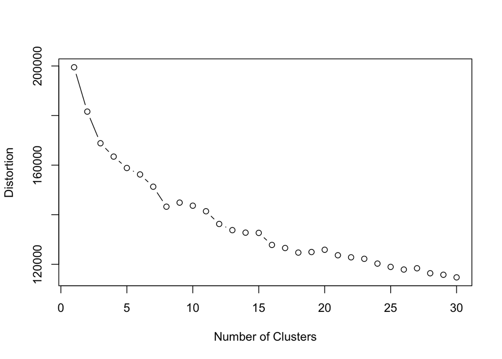

```r
# We can see that, of course, the distance decreases as we increase k.
# The gaps aren't too large, so we note that the elbow point must be somewhere around these points (note :
# it's highly likely to be for k = 5, as delta(6,5) = approx. 1000).

# However, to visualize this, we can best plot our distortions.
# Plot distortion at different k values (up to 30)
kmeans.dis <- function(data_z, maxk){
  dis=(nrow(data_z)-1)*sum(apply(data_z,2,var))
  dis[2:maxk]=sapply (2:maxk, kmeans.wss.k, tele_norm_cluster=tele_norm_cluster)
  return(dis) }
maxk = 30
dis = kmeans.dis(tele_norm_cluster, maxk)
plot(1:maxk, dis, type = 'b', xlab = "Number of Clusters", ylab = "Distortion", col = "black")
```

```r
# Again, cluster 5 appears to be the elbow point, whilst also being acceptable in terms of practicability
# (e.g., running 30 regression models would be highly impractical and not as insightful/useful from a business perspective)
```

> There seems to be an inflection point at k = 5, so we will use this number of clusters.

## 2.3 Clustering the data

```r
# Set another seed to save our cluster results
set.seed(123)

# Apply the k-means algorithm with 5 clusters
client_clusters <- kmeans(tele_norm_cluster, 5)

# Check cluster sizes
client_clusters$size
```

```
## [1] 8588 9763 7357 6206 9274
```

```r
# Thankfully, there's not a cluster that's overly large or small - this is a good sign! Too large would indicate that we could have used another cluster, whereas too small indicates too much specificity.

# Add the response variable back to the dataset to calculate success rates
tele_norm_cluster$y <- tele_norm$yyes

# Add a column with clusters for each individual call and factorize it
tele_norm_cluster$cluster <- client_clusters$cluster
tele_norm_cluster$cluster <- as.factor(tele_norm_cluster$cluster)

# Calculate success rates by cluster
success_by_segm <- tapply(tele_norm_cluster$y, tele_norm_cluster$cluster, mean, na.rm = T)
success_by_segm
```

```
##          1          2          3          4          5
## 0.23346530 0.05541330 0.19695528 0.04737351 0.03784775
```

> Through k-means clustering, we identified 5 clusters. The clusters had different call success rates. There were two clusters whose success rates were above the 16.7% threshold determined based on our per-call contribution margin. The other three clusters had significantly lower success rates. Therefore, we are going to apply our machine learning models to these clusters in order to optimize our targeting and, hopefully, achieve a higher success rate.

## 2.4 Preparing datasets for modeling

```r
# Create dataframes with the three clusters using conditional filtering
library(tidyverse)
normcluster2 <- tele_norm_cluster[tele_norm_cluster$cluster == 2,] %>% select(-cluster)
normcluster4 <- tele_norm_cluster[tele_norm_cluster$cluster == 4,] %>% select(-cluster)
normcluster5 <- tele_norm_cluster[tele_norm_cluster$cluster == 5,] %>% select(-cluster)
```

## 2.5 Let’s create train and test datasets for each cluster

```r
# Do an approximate 80-20 train-test split. We prevented hard-coding this by using the floor() function.

tele_train2 <- normcluster2[1:floor(0.8*nrow(normcluster2)),]
tele_test2 <- normcluster2[(floor(0.8*nrow(normcluster2)+1)):nrow(normcluster2),]

tele_train4 <- normcluster4[1:floor(0.8*nrow(normcluster4)),]
tele_test4 <- normcluster4[(floor(0.8*nrow(normcluster4)+1)):nrow(normcluster4),]

tele_train5 <- normcluster5[1:floor(0.8*nrow(normcluster5)),]
tele_test5 <- normcluster5[(floor(0.8*nrow(normcluster5)+1)):nrow(normcluster5),]
```

# 3 Logistic Regression

We have thankfully already cleaned the data up now. Additionally, Logistic Regression forces dummy variables and doesn’t need normalized values. So, we have to make sure that we create cluster sets that are *not normalized*.

## 3.1 Setting up our data

```r
# Thankfully, we set a seed before, so we can still create a new sample without messing up the order of rows and clusters.
set.seed(12345)
tele_random_log <- tele[sample(nrow(tele)),]

# The next step is to add a cluster column to our random log dataset.
tele_random_log$cluster <- client_clusters$cluster
head(tele_random_log)
```

```
##       age         job marital           education default housing loan
## 10904  32      admin. married         high.school      no      no   no
## 33373  29 blue-collar  single            basic.9y      no     yes   no
## 9986   39  technician married professional.course      no     yes   no
## 75     37      admin. married   university.degree unknown     yes   no
## 30311  28      admin.  single   university.degree      no      no  yes
## 26378  29 blue-collar married         high.school      no     yes   no
##         contact month day_of_week campaign previous    poutcome emp.var.rate
## 10904 telephone   jun         wed        1        0 nonexistent          1.4
## 33373  cellular   may         tue        1        1     failure         -1.8
## 9986  telephone   jun         wed        3        0 nonexistent          1.4
## 75    telephone   may         mon        1        0 nonexistent          1.1
## 30311 telephone   apr         thu        1        0 nonexistent         -1.8
## 26378  cellular   nov         thu        1        0 nonexistent         -0.1
##       cons.price.idx cons.conf.idx euribor3m nr.employed   y pdaysdummy cluster
## 10904         94.465         -41.8     4.962      5228.1  no          0       5
## 33373         92.893         -46.2     1.291      5099.1  no          0       3
## 9986          94.465         -41.8     4.959      5228.1  no          0       5
## 75            93.994         -36.4     4.857      5191.0  no          0       5
## 30311         93.075         -47.1     1.365      5099.1 yes          0       3
## 26378         93.200         -42.0     4.076      5195.8  no          0       4
```

```r
# And yes, that looks all good!

# Now, let's create train and test sets again for clusters 2, 4, and 5.
# We'll stick to the 80%/20% rule to maintain consistency in our comparisons.

cluster2 <- tele_random_log[tele_random_log$cluster == 2,] %>% select (-cluster)
cluster4 <- tele_random_log[tele_random_log$cluster == 4,] %>% select (-cluster)
cluster5 <- tele_random_log[tele_random_log$cluster == 5,] %>% select (-cluster)

tele_train2_log <- cluster2[1:nrow(tele_train2),]
tele_test2_log <- cluster2[(nrow(tele_train2)+1):nrow(cluster2),]

tele_train4_log <- cluster4[1:nrow(tele_train4),]
tele_test4_log <- cluster4[(nrow(tele_train4)+1):nrow(cluster4),]

tele_train5_log <- cluster5[1:nrow(tele_train5),]
tele_test5_log <- cluster5[(nrow(tele_train5)+1):nrow(cluster5),]

# In the meantime, let's store our test labels for the test set somewhere else..
tele_test2_log_labels <- tele_test2_log$y
tele_test4_log_labels <- tele_test4_log$y
tele_test5_log_labels <- tele_test5_log$y

# Of course, we now must remove the y from our test set.
tele_test2_log$y <- NULL
tele_test4_log$y <- NULL
tele_test5_log$y <- NULL
```

## 3.2 Running the initial prediction models

```r
predictionmodelt2 <- glm(y ~ ., data = tele_train2_log, family = "binomial")
summary(predictionmodelt2)
```

```
##
## Call:
## glm(formula = y ~ ., family = "binomial", data = tele_train2_log)
##
## Deviance Residuals:
##     Min       1Q   Median       3Q      Max
## -0.7381  -0.3639  -0.3258  -0.2896   2.7953
##
## Coefficients: (6 not defined because of singularities)
##                                Estimate Std. Error z value Pr(>|z|)
## (Intercept)                   -5.859413 921.804056  -0.006   0.9949
## age                           -0.009988   0.006494  -1.538   0.1240
## jobblue-collar                -0.354331   0.547227  -0.648   0.5173
## jobentrepreneur                0.049053   0.254275   0.193   0.8470
## jobhousemaid                  -0.789249   0.361029  -2.186   0.0288 *
## jobmanagement                  0.289455   0.176658   1.638   0.1013
## jobretired                     0.486049   0.258888   1.877   0.0605 .
## jobself-employed               0.311682   0.230002   1.355   0.1754
## jobservices                   -0.121063   0.206770  -0.585   0.5582
## jobstudent                    -0.035609   1.041703  -0.034   0.9727
## jobtechnician                  0.009959   0.151369   0.066   0.9475
## jobunemployed                 -0.196938   0.340688  -0.578   0.5632
## jobunknown                    -0.393755   0.643617  -0.612   0.5407
## maritalmarried                -0.019784   0.144455  -0.137   0.8911
## maritalsingle                 -0.073150   0.219883  -0.333   0.7394
## maritalunknown                 1.202926   0.675158   1.782   0.0748 .
## educationbasic.6y              0.009194   0.372930   0.025   0.9803
## educationbasic.9y             -0.181605   0.295176  -0.615   0.5384
## educationhigh.school          -0.143797   0.259500  -0.554   0.5795
## educationilliterate            1.529027   1.158399   1.320   0.1869
## educationprofessional.course  -0.446370   0.278336  -1.604   0.1088
## educationuniversity.degree    -0.253491   0.256315  -0.989   0.3227
## educationunknown              -0.118570   0.373832  -0.317   0.7511
## defaultunknown                -0.096995   0.132470  -0.732   0.4640
## defaultyes                   -11.212437 506.978830  -0.022   0.9824
## housingunknown                -0.149565   0.396801  -0.377   0.7062
## housingyes                     0.117159   0.102750   1.140   0.2542
## loanunknown                          NA         NA      NA       NA
## loanyes                        0.055679   0.132873   0.419   0.6752
## contacttelephone              -0.122631   0.324073  -0.378   0.7051
```

[output cut: 12 more lines]

```
## cons.price.idx                       NA         NA      NA       NA
## cons.conf.idx                        NA         NA      NA       NA
## euribor3m                      0.685873   1.710163   0.401   0.6884
## nr.employed                          NA         NA      NA       NA
## pdaysdummy                           NA         NA      NA       NA
## ---
## Signif. codes:  0 '***' 0.001 '**' 0.01 '*' 0.05 '.' 0.1 ' ' 1
##
## (Dispersion parameter for binomial family taken to be 1)
##
##     Null deviance: 3346.4  on 7809  degrees of freedom
## Residual deviance: 3291.6  on 7769  degrees of freedom
## AIC: 3373.6
##
## Number of Fisher Scoring iterations: 13
```

```r
predictionmodelt4 <- glm(y ~ ., data = tele_train4_log, family = "binomial")
summary(predictionmodelt4)
```

```
##
## Call:
## glm(formula = y ~ ., family = "binomial", data = tele_train4_log)
##
## Deviance Residuals:
##     Min       1Q   Median       3Q      Max
## -1.4232  -0.3504  -0.2882  -0.2333   2.9408
##
## Coefficients: (3 not defined because of singularities)
##                                Estimate Std. Error z value Pr(>|z|)
## (Intercept)                  -1.108e+03  8.573e+05  -0.001  0.99897
## age                          -1.482e-03  8.956e-03  -0.165  0.86858
## jobblue-collar                1.345e+01  1.195e+03   0.011  0.99102
## jobentrepreneur               5.674e-02  1.498e+03   0.000  0.99997
## jobhousemaid                  4.100e-01  1.540e+03   0.000  0.99979
## jobmanagement                -5.410e-02  1.604e+03   0.000  0.99997
## jobretired                    1.456e+01  1.195e+03   0.012  0.99028
## jobself-employed              1.840e-01  1.600e+03   0.000  0.99991
## jobservices                   1.711e-01  1.436e+03   0.000  0.99990
## jobtechnician                 1.551e+01  1.195e+03   0.013  0.98964
## jobunemployed                 5.947e-02  1.413e+03   0.000  0.99997
## maritalmarried               -3.532e-01  2.214e-01  -1.595  0.11074
## maritalsingle                -1.425e-01  2.747e-01  -0.519  0.60382
## maritalunknown               -1.388e+01  9.680e+02  -0.014  0.98856
## educationbasic.6y             4.572e-01  2.219e-01   2.061  0.03932 *
## educationbasic.9y             3.089e-01  1.919e-01   1.610  0.10745
## educationhigh.school          7.859e-01  2.729e-01   2.879  0.00398 **
## educationilliterate          -1.321e+01  1.070e+03  -0.012  0.99015
## educationprofessional.course  3.022e-01  3.670e-01   0.823  0.41029
## educationuniversity.degree    7.661e-01  1.054e+00   0.727  0.46749
## educationunknown             -1.348e-01  3.755e-01  -0.359  0.71966
## defaultunknown               -1.888e-02  1.453e-01  -0.130  0.89666
## housingunknown               -2.832e-01  4.327e-01  -0.654  0.51287
## housingyes                   -1.852e-01  1.376e-01  -1.345  0.17851
## loanunknown                          NA         NA      NA       NA
## loanyes                      -7.768e-02  1.974e-01  -0.394  0.69393
## contacttelephone             -4.572e-01  3.087e-01  -1.481  0.13864
## monthaug                     -6.757e+00  3.536e+03  -0.002  0.99848
## monthdec                      3.492e+00  4.244e+03   0.001  0.99934
## monthjul                      5.292e+00  5.408e+03   0.001  0.99922
```

[output cut: 13 more lines]

```
## cons.price.idx               -1.298e+00  3.866e+03   0.000  0.99973
## cons.conf.idx                 1.737e+00  1.302e+03   0.001  0.99894
## euribor3m                     2.605e+00  2.092e+00   1.245  0.21296
## nr.employed                   2.474e-01  1.280e+02   0.002  0.99846
## pdaysdummy                           NA         NA      NA       NA
## ---
## Signif. codes:  0 '***' 0.001 '**' 0.01 '*' 0.05 '.' 0.1 ' ' 1
##
## (Dispersion parameter for binomial family taken to be 1)
##
##     Null deviance: 1904.4  on 4963  degrees of freedom
## Residual deviance: 1832.8  on 4919  degrees of freedom
## AIC: 1922.8
##
## Number of Fisher Scoring iterations: 15
```

```r
predictionmodelt5 <- glm(y ~ ., data = tele_train5_log, family = "binomial")
```

```
## Error in `contrasts<-`(`*tmp*`, value = contr.funs[1 + isOF[nn]]): contrasts can be applied only to factors with 2 or more levels
```

```r
summary(predictionmodelt5)
```

```
## Error in summary(predictionmodelt5): object 'predictionmodelt5' not found
```

```r
# Unfortunately, we get an error here. It appears to be the case that for our tele_train5_log, we have a predictor variable which only has one level, causing the regression to fail. Let's find and fix this issue.
# To find the column with only one factorized value, we can use lapply() and unique as an argument.

lapply(tele_train5_log, unique)
```

```
## $age
##  [1] 32 39 37 35 52 45 51 28 31 47 38 33 44 50 34 46 27 41 26 36 25 60 58 42 30
## [26] 49 40 48 22 43 54 56 55 29 57 53 24 59 23 21 20 61
##
## $job
##  [1] admin.        technician    retired       management    services
##  [6] self-employed housemaid     entrepreneur  unemployed    student
## [11] blue-collar   unknown
## 12 Levels: admin. blue-collar entrepreneur housemaid management ... unknown
##
## $marital
## [1] married  single   divorced unknown
## Levels: divorced married single unknown
##
## $education
## [1] high.school         professional.course university.degree
## [4] basic.9y            basic.4y            basic.6y
## [7] unknown
## 8 Levels: basic.4y basic.6y basic.9y high.school ... unknown
##
## $default
## [1] no      unknown
## Levels: no unknown yes
##
## $housing
## [1] no      yes     unknown
## Levels: no unknown yes
##
## $loan
## [1] no      yes     unknown
## Levels: no unknown yes
##
## $contact
## [1] telephone
## Levels: cellular telephone
##
## $month
## [1] jun may jul nov aug oct dec
## Levels: apr aug dec jul jun mar may nov oct sep
##
```

[output cut: 25 more lines]

```
##  [1] 4.962 4.959 4.857 4.866 4.859 4.855 4.858 4.947 4.960 4.856 4.961 4.955
## [13] 4.865 4.864 4.860 4.963 4.120 4.076 4.958 4.967 4.153 4.968 4.964 4.956
## [25] 4.191 4.966 4.223 4.021 5.045 4.957 1.281 4.760 4.936 4.286 4.918 5.000
## [37] 4.406 4.912 4.921 4.343 4.663 1.354 4.733 4.965 4.700 4.474 4.794 3.282
## [49] 1.313 3.428 4.827 3.563 1.260 1.291
##
## $nr.employed
## [1] 5228.1 5191.0 5195.8 5099.1 5176.3 5076.2
##
## $y
## [1] no  yes
## Levels: no yes
##
## $pdaysdummy
## [1] 0
```

```r
# We see that the factor contact only has the value telephone. Let's confirm that.
sum(tele_train5_log$contact == "cellular")
```

```
## [1] 0
```

```r
sum(tele_train5_log$contact == "telephone")
```

```
## [1] 7419
```

```r
# So, the only solution here is to remove the contact variable from the train set.
tele_train5_log$contact <- NULL
# Note that pdaysdummy only contains the value 0 and is thus pointless in our glm. Let's remove that column, too.
tele_train5_log$pdaysdummy <- NULL

predictionmodelt5 <- glm(y ~ ., tele_train5_log, family = "binomial")
# now we get two more warnings, so let's fix those too.
# first, we see that two predictors are perfectly correlated. By merely looking at the dataset, we denote that this must be between previous and poutcome. Everyone who was called previously had a failure. Since multicollinearity can hurt our model, we must remove one of the variables.
# Yes, we must remove one variable. Let's choose to drop previous.

tele_train5_log$previous <- NULL

predictionmodelt5 <- glm(y ~ ., tele_train5_log, family = "binomial")
summary(predictionmodelt5)
```

```
##
## Call:
## glm(formula = y ~ ., family = "binomial", data = tele_train5_log)
##
## Deviance Residuals:
##    Min      1Q  Median      3Q     Max
##  -8.49    0.00    0.00    0.00    8.49
##
## Coefficients: (2 not defined because of singularities)
##                                Estimate Std. Error    z value Pr(>|z|)
## (Intercept)                   2.813e+25  1.391e+19    2021993   <2e-16 ***
## age                          -9.626e+11  1.006e+05   -9564212   <2e-16 ***
## jobblue-collar                9.871e+14  8.529e+06  115735205   <2e-16 ***
## jobentrepreneur               3.186e+14  3.615e+06   88130804   <2e-16 ***
## jobhousemaid                  4.532e+14  4.429e+06  102337911   <2e-16 ***
## jobmanagement                 2.527e+13  3.008e+06    8399442   <2e-16 ***
## jobretired                    6.302e+14  4.541e+06  138786174   <2e-16 ***
## jobself-employed             -3.223e+14  3.884e+06  -82974561   <2e-16 ***
## jobservices                   2.672e+14  2.551e+06  104720118   <2e-16 ***
## jobstudent                    1.267e+15  7.446e+06  170138278   <2e-16 ***
## jobtechnician                 1.060e+14  2.618e+06   40487723   <2e-16 ***
## jobunemployed                -2.975e+14  4.549e+06  -65397314   <2e-16 ***
## jobunknown                    4.722e+14  6.512e+06   72512599   <2e-16 ***
## maritalmarried                8.962e+13  2.405e+06   37265176   <2e-16 ***
## maritalsingle                 4.665e+14  2.864e+06  162882603   <2e-16 ***
## maritalunknown                1.588e+15  1.652e+07   96146866   <2e-16 ***
## educationbasic.6y            -1.055e+13  5.072e+06   -2080470   <2e-16 ***
## educationbasic.9y             1.506e+14  4.155e+06   36240327   <2e-16 ***
## educationhigh.school         -2.306e+13  3.701e+06   -6230810   <2e-16 ***
## educationprofessional.course  2.798e+13  4.090e+06    6841677   <2e-16 ***
## educationuniversity.degree    1.913e+14  3.694e+06   51786702   <2e-16 ***
## educationunknown             -8.094e+11  4.965e+06    -163029   <2e-16 ***
## defaultunknown                1.130e+13  1.865e+06    6057340   <2e-16 ***
## housingunknown               -7.004e+14  4.827e+06 -145110266   <2e-16 ***
## housingyes                   -1.948e+12  1.593e+06   -1222756   <2e-16 ***
## loanunknown                          NA         NA         NA       NA
## loanyes                      -9.196e+13  2.215e+06  -41514897   <2e-16 ***
## monthdec                     -1.316e+22  6.510e+15   -2021993   <2e-16 ***
## monthjul                      1.597e+23  7.900e+16    2021993   <2e-16 ***
## monthjun                      3.225e+23  1.595e+17    2021993   <2e-16 ***
```

[output cut: 9 more lines]

```
## emp.var.rate                  1.060e+23  5.241e+16    2021993   <2e-16 ***
## cons.price.idx               -3.017e+23  1.492e+17   -2021993   <2e-16 ***
## cons.conf.idx                 2.535e+21  1.254e+15    2021992   <2e-16 ***
## euribor3m                     1.491e+15  2.406e+07   61964033   <2e-16 ***
## nr.employed                          NA         NA         NA       NA
## ---
## Signif. codes:  0 '***' 0.001 '**' 0.01 '*' 0.05 '.' 0.1 ' ' 1
##
## (Dispersion parameter for binomial family taken to be 1)
##
##     Null deviance:  2312.7  on 7418  degrees of freedom
## Residual deviance: 19175.2  on 7377  degrees of freedom
## AIC: 19259
##
## Number of Fisher Scoring iterations: 22
```

> The thing is that our models are nowhere near strong. We still have tons of variables that will likely be highly multicollinear, and we actually must remove variables before we can run predictions. Below is explained why.

## 3.3 Using Logistic Regression on the Test Data - why it doesn’t “just” work.

```r
binarypredictionlogt2 <- ifelse(predict(predictionmodelt2, newdata = tele_test2_log, type = "response") < 0.5, 0, 1)
```

```
## Error in model.frame.default(Terms, newdata, na.action = na.action, xlev = object$xlevels): factor month has new levels oct
```

```r
binarypredictionlogt4 <- ifelse(predict(predictionmodelt4, newdata = tele_test4_log, type = "response") < 0.5, 0, 1)
```

```
## Error in model.frame.default(Terms, newdata, na.action = na.action, xlev = object$xlevels): factor job has new levels unknown
```

```r
binarypredictionlogt5 <- ifelse(predict(predictionmodelt5, newdata = tele_test5_log, type = "response") < 0.5, 0, 1)
## In all prediction models, we have the issue that our test dataset has some values for "month" that aren't in the train set. R now has no clue how, for instance, October impacts the y column, and thus cannot run predictions.
```

## 3.4 Removing Columns in Logistic Regression

```r
# CLUSTER 2!!!!!!

improvedpredictionmodelt2 <- glm(y ~ job + marital + month, data = tele_train2_log, family = "binomial")
summary(improvedpredictionmodelt2)
```

```
##
## Call:
## glm(formula = y ~ job + marital + month, family = "binomial",
##     data = tele_train2_log)
##
## Deviance Residuals:
##     Min       1Q   Median       3Q      Max
## -0.7988  -0.3650  -0.3246  -0.3048   2.7616
##
## Coefficients:
##                    Estimate Std. Error z value Pr(>|z|)
## (Intercept)       -2.923254   0.164840 -17.734  < 2e-16 ***
## jobblue-collar    -0.248574   0.521550  -0.477  0.63364
## jobentrepreneur    0.037000   0.250817   0.148  0.88272
## jobhousemaid      -0.701353   0.334401  -2.097  0.03596 *
## jobmanagement      0.258784   0.173926   1.488  0.13678
## jobretired         0.384175   0.225185   1.706  0.08800 .
## jobself-employed   0.267016   0.224840   1.188  0.23500
## jobservices       -0.064344   0.193910  -0.332  0.74002
## jobstudent         0.008810   1.035811   0.009  0.99321
## jobtechnician     -0.077188   0.132928  -0.581  0.56146
## jobunemployed     -0.211780   0.337138  -0.628  0.52989
## jobunknown        -0.371312   0.619265  -0.600  0.54877
## maritalmarried     0.006394   0.142739   0.045  0.96427
## maritalsingle      0.028843   0.210973   0.137  0.89126
## maritalunknown     1.365154   0.669770   2.038  0.04153 *
## monthdec          -8.565611 196.967752  -0.043  0.96531
## monthjul           0.312526   0.120848   2.586  0.00971 **
## monthnov          -0.166249   0.148882  -1.117  0.26414
## ---
## Signif. codes:  0 '***' 0.001 '**' 0.01 '*' 0.05 '.' 0.1 ' ' 1
##
## (Dispersion parameter for binomial family taken to be 1)
##
##     Null deviance: 3346.4  on 7809  degrees of freedom
## Residual deviance: 3315.5  on 7792  degrees of freedom
## AIC: 3351.5
##
## Number of Fisher Scoring iterations: 10
```

```r
# CLUSTER 4!!!!!!
# Let's remove the month column.
# We first realized the singularities warning message. This means that one variable is perfectly correlated to the other.
# we can use alias() to find which ones.

alias(predictionmodelt4)
```

```
## Model :
## y ~ age + job + marital + education + default + housing + loan +
##     contact + month + day_of_week + campaign + previous + poutcome +
##     emp.var.rate + cons.price.idx + cons.conf.idx + euribor3m +
##     nr.employed + pdaysdummy
##
## Complete :
##                     (Intercept) age jobblue-collar jobentrepreneur jobhousemaid
## loanunknown          0           0   0              0               0
## poutcomenonexistent  1           0   0              0               0
## pdaysdummy           0           0   0              0               0
##                     jobmanagement jobretired jobself-employed jobservices
## loanunknown          0             0          0                0
## poutcomenonexistent  0             0          0                0
## pdaysdummy           0             0          0                0
##                     jobtechnician jobunemployed maritalmarried maritalsingle
## loanunknown          0             0             0              0
## poutcomenonexistent  0             0             0              0
## pdaysdummy           0             0             0              0
##                     maritalunknown educationbasic.6y educationbasic.9y
## loanunknown          0              0                 0
## poutcomenonexistent  0              0                 0
## pdaysdummy           0              0                 0
##                     educationhigh.school educationilliterate
## loanunknown          0                    0
## poutcomenonexistent  0                    0
## pdaysdummy           0                    0
##                     educationprofessional.course educationuniversity.degree
## loanunknown          0                            0
## poutcomenonexistent  0                            0
## pdaysdummy           0                            0
##                     educationunknown defaultunknown housingunknown housingyes
## loanunknown          0                0              1              0
## poutcomenonexistent  0                0              0              0
## pdaysdummy           0                0              0              0
##                     loanyes contacttelephone monthaug monthdec monthjul
## loanunknown          0       0                0        0        0
## poutcomenonexistent  0       0                0        0        0
## pdaysdummy           0       0                0        0        0
##                     monthjun monthmay monthnov monthoct day_of_weekmon
## loanunknown          0        0        0        0        0
## poutcomenonexistent  0        0        0        0        0
## pdaysdummy           0        0        0        0        0
##                     day_of_weekthu day_of_weektue day_of_weekwed campaign
## loanunknown          0              0              0              0
## poutcomenonexistent  0              0              0              0
## pdaysdummy           0              0              0              0
##                     previous poutcomesuccess emp.var.rate cons.price.idx
## loanunknown          0        0               0            0
## poutcomenonexistent -1        0               0            0
## pdaysdummy           0        1               0            0
##                     cons.conf.idx euribor3m nr.employed
## loanunknown          0             0         0
## poutcomenonexistent  0             0         0
## pdaysdummy           0             0         0
```

```r
# Okay, so pdaysdummy is perfectly correlated to one value of poutcome. Let's drop pdaysdummy too, then.

# Improvement procedure: sequentially remove variables with p > 0.10.

improvedpredictionmodelt4 <- glm(y ~ education + contact + day_of_week + poutcome + euribor3m + nr.employed, data = tele_train4_log, family = "binomial")
summary(improvedpredictionmodelt4)
```

```
##
## Call:
## glm(formula = y ~ education + contact + day_of_week + poutcome +
##     euribor3m + nr.employed, family = "binomial", data = tele_train4_log)
##
## Deviance Residuals:
##     Min       1Q   Median       3Q      Max
## -0.9898  -0.3510  -0.2979  -0.2398   2.8309
##
## Coefficients:
##                               Estimate Std. Error z value Pr(>|z|)
## (Intercept)                  -79.11726   27.37339  -2.890  0.00385 **
## educationbasic.6y              0.44245    0.21581   2.050  0.04034 *
## educationbasic.9y              0.32588    0.18216   1.789  0.07361 .
## educationhigh.school           0.79045    0.26545   2.978  0.00290 **
## educationilliterate          -11.29686  393.04319  -0.029  0.97707
## educationprofessional.course   0.31461    0.35871   0.877  0.38046
## educationuniversity.degree     0.71475    1.05139   0.680  0.49662
## educationunknown              -0.07229    0.37187  -0.194  0.84586
## contacttelephone              -0.33111    0.15450  -2.143  0.03210 *
## day_of_weekmon                -0.38475    0.21182  -1.816  0.06931 .
## day_of_weekthu                -0.15648    0.20156  -0.776  0.43754
## day_of_weektue                -0.37481    0.21229  -1.766  0.07747 .
## day_of_weekwed                -0.33017    0.20721  -1.593  0.11107
## poutcomenonexistent            0.80822    0.73291   1.103  0.27013
## poutcomesuccess                2.80924    1.42622   1.970  0.04887 *
## euribor3m                     -0.63800    0.22628  -2.820  0.00481 **
## nr.employed                    0.01507    0.00541   2.785  0.00535 **
## ---
## Signif. codes:  0 '***' 0.001 '**' 0.01 '*' 0.05 '.' 0.1 ' ' 1
##
## (Dispersion parameter for binomial family taken to be 1)
##
##     Null deviance: 1904.4  on 4963  degrees of freedom
## Residual deviance: 1859.2  on 4947  degrees of freedom
## AIC: 1893.2
##
## Number of Fisher Scoring iterations: 13
```

```r
# CLUSTER 5!!!!!!
# Let's remove nr.employed first because it contains NA's.
improvedpredictionmodelt5 <- glm(y ~. - nr.employed, data = tele_train5_log, family = "binomial")
summary(improvedpredictionmodelt5)
```

```
##
## Call:
## glm(formula = y ~ . - nr.employed, family = "binomial", data = tele_train5_log)
##
## Deviance Residuals:
##     Min       1Q   Median       3Q      Max
## -1.6297  -0.2804  -0.2446  -0.2185   2.9685
##
## Coefficients: (2 not defined because of singularities)
##                                Estimate Std. Error z value Pr(>|z|)
## (Intercept)                   1.551e+04  2.795e+06   0.006   0.9956
## age                           1.375e-03  8.358e-03   0.164   0.8694
## jobblue-collar                6.542e-01  5.449e-01   1.201   0.2299
## jobentrepreneur               2.498e-01  2.726e-01   0.916   0.3596
## jobhousemaid                  1.769e-01  3.691e-01   0.479   0.6317
## jobmanagement                 1.168e-02  2.537e-01   0.046   0.9633
## jobretired                    2.727e-01  3.603e-01   0.757   0.4492
## jobself-employed             -3.850e-01  3.729e-01  -1.032   0.3019
## jobservices                   2.541e-01  2.096e-01   1.213   0.2253
## jobstudent                    8.206e-01  4.287e-01   1.914   0.0556 .
## jobtechnician                 3.886e-02  2.164e-01   0.180   0.8575
## jobunemployed                -2.583e-01  4.376e-01  -0.590   0.5550
## jobunknown                    4.170e-01  4.874e-01   0.856   0.3922
## maritalmarried                1.246e-01  2.095e-01   0.595   0.5521
## maritalsingle                 4.491e-01  2.416e-01   1.859   0.0631 .
## maritalunknown               -1.419e+01  9.391e+02  -0.015   0.9879
## educationbasic.6y            -1.310e-02  4.402e-01  -0.030   0.9763
## educationbasic.9y             2.052e-01  3.463e-01   0.593   0.5534
## educationhigh.school          1.156e-02  3.144e-01   0.037   0.9707
## educationprofessional.course  2.950e-02  3.495e-01   0.084   0.9327
## educationuniversity.degree    1.972e-01  3.122e-01   0.632   0.5276
## educationunknown              1.622e-02  4.208e-01   0.039   0.9693
## defaultunknown               -2.362e-02  1.571e-01  -0.150   0.8805
## housingunknown               -1.485e+00  7.264e-01  -2.044   0.0409 *
## housingyes                   -9.201e-03  1.297e-01  -0.071   0.9434
## loanunknown                          NA         NA      NA       NA
## loanyes                      -9.951e-02  1.864e-01  -0.534   0.5935
## monthdec                     -1.568e+01  3.444e+03  -0.005   0.9964
## monthjul                      9.302e+01  1.430e+04   0.007   0.9948
## monthjun                      1.851e+02  3.073e+04   0.006   0.9952
```

[output cut: 8 more lines]

```
## poutcomenonexistent          -4.881e-01  9.249e-01  -0.528   0.5977
## emp.var.rate                  5.937e+01  1.142e+04   0.005   0.9959
## cons.price.idx               -1.672e+02  3.009e+04  -0.006   0.9956
## cons.conf.idx                        NA         NA      NA       NA
## euribor3m                     2.749e+00  1.225e+00   2.243   0.0249 *
## ---
## Signif. codes:  0 '***' 0.001 '**' 0.01 '*' 0.05 '.' 0.1 ' ' 1
##
## (Dispersion parameter for binomial family taken to be 1)
##
##     Null deviance: 2312.7  on 7418  degrees of freedom
## Residual deviance: 2160.6  on 7378  degrees of freedom
## AIC: 2242.6
##
## Number of Fisher Scoring iterations: 16
```

```r
# We see that, thankfully, now we have more realistic p-values! We can now use our normal procedure to refine the regression.

improvedpredictionmodelt5 <- glm(y ~ job + marital + housing + euribor3m, data = tele_train5_log, family = "binomial")
summary(improvedpredictionmodelt5)
```

```
##
## Call:
## glm(formula = y ~ job + marital + housing + euribor3m, family = "binomial",
##     data = tele_train5_log)
##
## Deviance Residuals:
##     Min       1Q   Median       3Q      Max
## -0.6013  -0.2889  -0.2641  -0.2561   3.0707
##
## Coefficients:
##                    Estimate Std. Error z value Pr(>|z|)
## (Intercept)       -1.067960   1.232821  -0.866   0.3863
## jobblue-collar     0.420488   0.536420   0.784   0.4331
## jobentrepreneur    0.361664   0.254596   1.421   0.1555
## jobhousemaid       0.003120   0.344055   0.009   0.9928
## jobmanagement     -0.034378   0.243460  -0.141   0.8877
## jobretired         0.203955   0.319294   0.639   0.5230
## jobself-employed  -0.352899   0.357686  -0.987   0.3238
## jobservices        0.055982   0.191923   0.292   0.7705
## jobstudent         0.730792   0.420464   1.738   0.0822 .
## jobtechnician     -0.006045   0.185849  -0.033   0.9741
## jobunemployed     -0.388577   0.429805  -0.904   0.3660
## jobunknown         0.386499   0.436149   0.886   0.3755
## maritalmarried     0.076461   0.199907   0.382   0.7021
## maritalsingle      0.290209   0.221737   1.309   0.1906
## maritalunknown   -12.226067 352.144972  -0.035   0.9723
## housingunknown    -1.382313   0.715964  -1.931   0.0535 .
## housingyes        -0.018450   0.125595  -0.147   0.8832
## euribor3m         -0.481200   0.255130  -1.886   0.0593 .
## ---
## Signif. codes:  0 '***' 0.001 '**' 0.01 '*' 0.05 '.' 0.1 ' ' 1
##
## (Dispersion parameter for binomial family taken to be 1)
##
##     Null deviance: 2312.7  on 7418  degrees of freedom
## Residual deviance: 2290.7  on 7401  degrees of freedom
## AIC: 2326.7
##
## Number of Fisher Scoring iterations: 14
```